# Reshaping and Joining Data in R with dplyr

## 🚩checkpoint: group verbs

Your turn!

Let’s return to our goal of creating a table with one row per year that gives us the percentage of groundhogs that saw their shadow that year. Create a dataframe with three variables:

- year
- the number of total predictions made in each year
- the number of total shadows seen each year

## 🚩checkpoint: group verbs

```r
# Create a dataframe with 3 variables:
# year
# the number of total predictions made that year
# the number of total shadows seen that year
predictions |>
  group_by(year) |>
  summarize(n_predictions = n(),
            n_shadows = sum(shadow == TRUE))
```

| year | n_predictions | n_shadows |
| --- | --- | --- |
| 1887 | 1 | 1 |
| 1888 | 1 | 1 |
| 1890 | 1 | 0 |
| 1898 | 1 | 1 |
| 1900 | 1 | 1 |
| 1901 | 1 | 1 |
| 1902 | 1 | 0 |
| 1903 | 1 | 1 |
| 1904 | 1 | 1 |
| 1905 | 1 | 1 |

[output cut: 118 more lines]

## column verbs

Now that we’ve calculated some summary variables within the groups that interest us (groundhog and year), we might want to use those summary variables to calculate more new variables.

- `mutate()` adds new columns calculated from existing columns
- `select()` keeps a subset of columns
- `rename()` renames columns

## column verbs: `mutate()`

`mutate()` adds new columns calculated from existing columns

```r
# calculate how many characters are in the details field and put the variable after id
predictions |>
  mutate(details_length = nchar(details), .after = id)
```

| id | details_length | year | shadow | details |
| --- | --- | --- | --- | --- |
| 1 | 158 | 2023 | TRUE | Shadow at 7:24 AM; 13º with clear skies. PA Governor Josh Shapiro attends. Thousands of Eagles Super Bowl LVII fans help celebrate Phil’s big day at the Knob. |
| 2 | NA | 2023 | FALSE | NA |
| 3 | 24 | 2023 | FALSE | No Shadow, Early Spring! |
| 4 | NA | 2023 | TRUE | NA |
| 5 | NA | 2023 | FALSE | NA |
| 6 | NA | 2023 | TRUE | NA |
| 7 | NA | 2023 | FALSE | NA |
| 8 | NA | 2023 | FALSE | NA |
| 9 | NA | 2023 | TRUE | NA |
| 10 | NA | 2023 | FALSE | NA |

[output cut: 1307 more lines]

## re-coding data with `mutate()`

`if_else()` tests for a condition and returns one value if true and another if false.

```r
# create a column that indicates whether the prediction was made by Punxatawney Phil
predictions |>
  mutate(phil = if_else(id == 1, 'TRUE', 'FALSE'))
```

| id | year | shadow | details | phil |
| --- | --- | --- | --- | --- |
| 1 | 2023 | TRUE | Shadow at 7:24 AM; 13º with clear skies. PA Governor Josh Shapiro attends. Thousands of Eagles Super Bowl LVII fans help celebrate Phil’s big day at the Knob. | TRUE |
| 2 | 2023 | FALSE | NA | FALSE |
| 3 | 2023 | FALSE | No Shadow, Early Spring! | FALSE |
| 4 | 2023 | TRUE | NA | FALSE |
| 5 | 2023 | FALSE | NA | FALSE |
| 6 | 2023 | TRUE | NA | FALSE |
| 7 | 2023 | FALSE | NA | FALSE |
| 8 | 2023 | FALSE | NA | FALSE |
| 9 | 2023 | TRUE | NA | FALSE |
| 10 | 2023 | FALSE | NA | FALSE |

[output cut: 1307 more lines]

## re-coding data with `mutate()`

`case_when()` tests for multiple conditions and maps them to values accordingly.

```r
# create a column that indicates the century of the predictions
predictions |>
  mutate(century = case_when(year < 1900 ~ '19',
                             year < 2000 & year >= 1900 ~ '20',
                             year >= 2000 ~ '21',
                             TRUE ~ 'Year out of range'))
```

| id | year | shadow | details | century |
| --- | --- | --- | --- | --- |
| 1 | 2023 | TRUE | Shadow at 7:24 AM; 13º with clear skies. PA Governor Josh Shapiro attends. Thousands of Eagles Super Bowl LVII fans help celebrate Phil’s big day at the Knob. | 21 |
| 2 | 2023 | FALSE | NA | 21 |
| 3 | 2023 | FALSE | No Shadow, Early Spring! | 21 |
| 4 | 2023 | TRUE | NA | 21 |
| 5 | 2023 | FALSE | NA | 21 |
| 6 | 2023 | TRUE | NA | 21 |
| 7 | 2023 | FALSE | NA | 21 |
| 8 | 2023 | FALSE | NA | 21 |
| 9 | 2023 | TRUE | NA | 21 |
| 10 | 2023 | FALSE | NA | 21 |

[output cut: 1307 more lines]

## column verbs: `select()` and `rename()`

- `select()` keeps a subset of columns
  - You can select by name, series, test for data type (`select(where(is.character()))`) or use other helper functions such as `starts_with()`, `ends_with()`, or `contains()`
  - You can rename variables as you select them with `=` , with the new name on the left and old on the right
- `rename()` works the same way as renaming in select with `=`

## 🚩checkpoint: put it all together!

```r
year_predictions <- predictions |>
  group_by(year) |>
  summarize(n_predictions = n(),
            n_shadows = sum(shadow == TRUE)) |>
  mutate(shadow_percent = n_shadows/n_predictions) |>
  filter(n_predictions > 5) |>
  select(year, shadow_percent) |>
  rename(prediction_year = year)
```

## table verbs: joining data

We’ve focused on **year** as our main unit of analysis so far, and learned a lot with the mere 4 variables in our `predictions` table!

Let’s turn our attention to the `groundhogs` table - some of these groundhogs are not like the others…

If we wanted to filter out “alternative groundhogs” from the prediction calculations, we need information from the `groundhogs` table.

```r
head(groundhogs)
```

| id | slug | shortname | name | city | region | country | latitude | longitude | source | current_prediction | is_groundhog | type | active | description | image | predictions_count |
| --- | --- | --- | --- | --- | --- | --- | --- | --- | --- | --- | --- | --- | --- | --- | --- | --- |
| 1 | punxsutawney-phil | Phil | Punxsutawney Phil | Punxsutawney | Pennsylvania | USA | 40.93120 | -78.96225 | https://www.groundhog.org/history-past-predictions | https://www.cbsnews.com/news/groundhog-day-2023-punxsutawney-phil-prediction/ | TRUE | Groundhog | TRUE | Punxsutawney Phil is a superstar prognosticating groundhog from Punxsutawney, Pennsylvania. He makes his predictions from his burrow on Gobler’s Knob. According to legend, Phil has made weather progno… | https://groundhog-day.com/images/ghogs/punxsutawney-phil.jpeg | 128 |
| 2 | octoraro-orphie | Orphie | Octoraro Orphie | Quarryville | Pennsylvania | USA | 39.82554 | -76.09196 | http://home.ptd.net/\\%7Emsvitale/index.html | https://lancasteronline.com/news/local/groundhog-day-2023-heres-what-punxsutawney-phil-lancaster-county-groundhogs-predict-video/article_cf5ef140-a187-11ed-814b-d74d34d45df1.html | FALSE | Taxidermied groundhog | TRUE | Octoraro Orphie, from Quarryville Pennsylvania, is a taxidermied world-renowned weather prognosticator and “One True Groundhog.” Other so-called groundhogs draw more celebrity endorsements, but Orphie… | https://groundhog-day.com/images/ghogs/octoraro-orphie.jpeg | 91 |
| 3 | wiarton-willie | Willie | Wiarton Willie | Wiarton | Ontario | Canada | 44.74387 | -81.13868 | https://www.southbrucepeninsula.com/en/explore-and-play/wiarton-willie.aspx#Past-predictions | https://twitter.com/WiartonWillie/status/1621137992860729346 | TRUE | Groundhog | TRUE | Wiarton Wille is Canada’s most famous prognosticating groundhog, from the town of Wiarton, Ontario. Willie is a white groundhog whose coming was foretold as one who would forever alter the world of we… | https://groundhog-day.com/images/ghogs/wiarton-willie.jpeg | 60 |
| 4 | jimmy-the-groundhog | Jimmy | Jimmy the Groundhog | Sun Prairie | Wisconsin | USA | 43.18263 | -89.21432 | https://www.cityofsunprairie.com/840/Groundhog-Day | https://www.nbc15.com/2023/02/02/jimmy-gears-up-75th-annual-groundhog-day-sun-prairie/ | TRUE | Groundhog | TRUE | Jimmy the Groundhog is based in Sun Prairie, Wisconsin, the proclaimed “World Headquarters of the Groundhog.” His annual emergence from the ground on February 2nd foretells the coming of spring. Jimmy… | https://groundhog-day.com/images/ghogs/jimmy-the-groundhog.jpeg | 55 |
| 5 | concord-charlie | Charlie | Concord Charlie | Athens | West Virginia | USA | 37.42460 | -81.00959 | https://www.concord.edu/?s=concord+charlie | https://www.bdtonline.com/news/concord-charlie-says-winter-is-over/article_7803c03e-a307-11ed-bc20-ef9089191257.html | FALSE | Presumed groundhog | TRUE | Concord Charlie is a presumed groundhog from Athens, West Virginia. In a tradition dating back to 1978, Charlie meets with the President of Concord University and relays his predictions regarding the … | https://groundhog-day.com/images/ghogs/concord-charlie.jpeg | 45 |
| 6 | buckeye-chuck | Chuck | Buckeye Chuck | Marion | Ohio | USA | 40.61413 | -83.13215 | https://en.wikipedia.org/wiki/Buckeye_Chuck#Past_predictions | https://twitter.com/OHBuckeyeChuck/status/1621127073598160899 | TRUE | Groundhog | TRUE | Buckeye Chuck is a weather-predicting groundhog in Marion, Ohio. In 1979, the Ohio legislature named Chuck the official groundhog for the Ohio state. Buckeye Chuck lives a comfortable, celebrity lifes… | https://groundhog-day.com/images/ghogs/buckeye-chuck.jpeg | 40 |

## join terminology

There are two main types of join:

- **mutating joins** add variables from one dataframe to another based on matching characteristics between the two
- **filtering joins** subset one dataframe based on matching characteristics with another dataframe

## primary & foreign keys🗝️

- Every join involves a **primary key** and a **foreign key**
  - A primary key is a variable or set of variables that **uniquely** identifies an observation
  - A foreign key is a variable or set of variables that matches your tables’ primary key. It might have a different name, be spread across more or less variables, and it may or may not be unique.
- The first step when joining data is to identify the primary keys of each table.

## types of joins

- **one-to-one joins** connect a single observation in one table to a single observation in another table. This happens when both the primary and foreign keys are unique.
- **one-to-many joins** connect a single observation in one table to many observations in another table. This happens when the foreign key is not unique.

## joining predictions & groundhogs

What is the primary key of `predictions`? What about `groundhogs`?

```r
head(predictions)
```

| id | year | shadow | details |
| --- | --- | --- | --- |
| 1 | 2023 | TRUE | Shadow at 7:24 AM; 13º with clear skies. PA Governor Josh Shapiro attends. Thousands of Eagles Super Bowl LVII fans help celebrate Phil’s big day at the Knob. |
| 2 | 2023 | FALSE | NA |
| 3 | 2023 | FALSE | No Shadow, Early Spring! |
| 4 | 2023 | TRUE | NA |
| 5 | 2023 | FALSE | NA |
| 6 | 2023 | TRUE | NA |

```r
head(groundhogs)
```

| id | slug | shortname | name | city | region | country | latitude | longitude | source | current_prediction | is_groundhog | type | active | description | image | predictions_count |
| --- | --- | --- | --- | --- | --- | --- | --- | --- | --- | --- | --- | --- | --- | --- | --- | --- |
| 1 | punxsutawney-phil | Phil | Punxsutawney Phil | Punxsutawney | Pennsylvania | USA | 40.93120 | -78.96225 | https://www.groundhog.org/history-past-predictions | https://www.cbsnews.com/news/groundhog-day-2023-punxsutawney-phil-prediction/ | TRUE | Groundhog | TRUE | Punxsutawney Phil is a superstar prognosticating groundhog from Punxsutawney, Pennsylvania. He makes his predictions from his burrow on Gobler’s Knob. According to legend, Phil has made weather progno… | https://groundhog-day.com/images/ghogs/punxsutawney-phil.jpeg | 128 |
| 2 | octoraro-orphie | Orphie | Octoraro Orphie | Quarryville | Pennsylvania | USA | 39.82554 | -76.09196 | http://home.ptd.net/\\%7Emsvitale/index.html | https://lancasteronline.com/news/local/groundhog-day-2023-heres-what-punxsutawney-phil-lancaster-county-groundhogs-predict-video/article_cf5ef140-a187-11ed-814b-d74d34d45df1.html | FALSE | Taxidermied groundhog | TRUE | Octoraro Orphie, from Quarryville Pennsylvania, is a taxidermied world-renowned weather prognosticator and “One True Groundhog.” Other so-called groundhogs draw more celebrity endorsements, but Orphie… | https://groundhog-day.com/images/ghogs/octoraro-orphie.jpeg | 91 |
| 3 | wiarton-willie | Willie | Wiarton Willie | Wiarton | Ontario | Canada | 44.74387 | -81.13868 | https://www.southbrucepeninsula.com/en/explore-and-play/wiarton-willie.aspx#Past-predictions | https://twitter.com/WiartonWillie/status/1621137992860729346 | TRUE | Groundhog | TRUE | Wiarton Wille is Canada’s most famous prognosticating groundhog, from the town of Wiarton, Ontario. Willie is a white groundhog whose coming was foretold as one who would forever alter the world of we… | https://groundhog-day.com/images/ghogs/wiarton-willie.jpeg | 60 |
| 4 | jimmy-the-groundhog | Jimmy | Jimmy the Groundhog | Sun Prairie | Wisconsin | USA | 43.18263 | -89.21432 | https://www.cityofsunprairie.com/840/Groundhog-Day | https://www.nbc15.com/2023/02/02/jimmy-gears-up-75th-annual-groundhog-day-sun-prairie/ | TRUE | Groundhog | TRUE | Jimmy the Groundhog is based in Sun Prairie, Wisconsin, the proclaimed “World Headquarters of the Groundhog.” His annual emergence from the ground on February 2nd foretells the coming of spring. Jimmy… | https://groundhog-day.com/images/ghogs/jimmy-the-groundhog.jpeg | 55 |
| 5 | concord-charlie | Charlie | Concord Charlie | Athens | West Virginia | USA | 37.42460 | -81.00959 | https://www.concord.edu/?s=concord+charlie | https://www.bdtonline.com/news/concord-charlie-says-winter-is-over/article_7803c03e-a307-11ed-bc20-ef9089191257.html | FALSE | Presumed groundhog | TRUE | Concord Charlie is a presumed groundhog from Athens, West Virginia. In a tradition dating back to 1978, Charlie meets with the President of Concord University and relays his predictions regarding the … | https://groundhog-day.com/images/ghogs/concord-charlie.jpeg | 45 |
| 6 | buckeye-chuck | Chuck | Buckeye Chuck | Marion | Ohio | USA | 40.61413 | -83.13215 | https://en.wikipedia.org/wiki/Buckeye_Chuck#Past_predictions | https://twitter.com/OHBuckeyeChuck/status/1621127073598160899 | TRUE | Groundhog | TRUE | Buckeye Chuck is a weather-predicting groundhog in Marion, Ohio. In 1979, the Ohio legislature named Chuck the official groundhog for the Ohio state. Buckeye Chuck lives a comfortable, celebrity lifes… | https://groundhog-day.com/images/ghogs/buckeye-chuck.jpeg | 40 |

## joining predictions & groundhogs

- How would we combine the data in `groundhogs` and `predictions`, if we wanted to see all columns from both tables together?
- primary key: `id` in `groundhogs` (unique)
- foreign key: `id` in `predictions` (not unique)

## joining predictions & groundhogs

- We’ll need a **mutating join**, and we’re going to use an **inner** **join**
- An **inner join** keeps all rows from both tables, as long as the keys appear in both
- `inner_join(x, y, join_by(x.key == y.key))`
- `predictions` contains 1317 unique predictions, and `groundhogs` contains 75 unique groundhogs. Every groundhog in `predictions` appears in `groundhogs` and vice versa. How many rows will our joined table have?

## joining predictions & groundhogs

```r
inner_join(predictions, groundhogs, join_by(id == id))
```

| id | year | shadow | details | slug | shortname | name | city | region | country | latitude | longitude | source | current_prediction | is_groundhog | type | active | description | image | predictions_count |
| --- | --- | --- | --- | --- | --- | --- | --- | --- | --- | --- | --- | --- | --- | --- | --- | --- | --- | --- | --- |
| 1 | 2023 | TRUE | Shadow at 7:24 AM; 13º with clear skies. PA Governor Josh Shapiro attends. Thousands of Eagles Super Bowl LVII fans help celebrate Phil’s big day at the Knob. | punxsutawney-phil | Phil | Punxsutawney Phil | Punxsutawney | Pennsylvania | USA | 40.93120 | -78.96225 | https://www.groundhog.org/history-past-predictions | https://www.cbsnews.com/news/groundhog-day-2023-punxsutawney-phil-prediction/ | TRUE | Groundhog | TRUE | Punxsutawney Phil is a superstar prognosticating groundhog from Punxsutawney, Pennsylvania. He makes his predictions from his burrow on Gobler’s Knob. According to legend, Phil has made weather progno… | https://groundhog-day.com/images/ghogs/punxsutawney-phil.jpeg | 128 |
| 2 | 2023 | FALSE | NA | octoraro-orphie | Orphie | Octoraro Orphie | Quarryville | Pennsylvania | USA | 39.82554 | -76.09196 | http://home.ptd.net/\\%7Emsvitale/index.html | https://lancasteronline.com/news/local/groundhog-day-2023-heres-what-punxsutawney-phil-lancaster-county-groundhogs-predict-video/article_cf5ef140-a187-11ed-814b-d74d34d45df1.html | FALSE | Taxidermied groundhog | TRUE | Octoraro Orphie, from Quarryville Pennsylvania, is a taxidermied world-renowned weather prognosticator and “One True Groundhog.” Other so-called groundhogs draw more celebrity endorsements, but Orphie… | https://groundhog-day.com/images/ghogs/octoraro-orphie.jpeg | 91 |
| 3 | 2023 | FALSE | No Shadow, Early Spring! | wiarton-willie | Willie | Wiarton Willie | Wiarton | Ontario | Canada | 44.74387 | -81.13868 | https://www.southbrucepeninsula.com/en/explore-and-play/wiarton-willie.aspx#Past-predictions | https://twitter.com/WiartonWillie/status/1621137992860729346 | TRUE | Groundhog | TRUE | Wiarton Wille is Canada’s most famous prognosticating groundhog, from the town of Wiarton, Ontario. Willie is a white groundhog whose coming was foretold as one who would forever alter the world of we… | https://groundhog-day.com/images/ghogs/wiarton-willie.jpeg | 60 |
| 4 | 2023 | TRUE | NA | jimmy-the-groundhog | Jimmy | Jimmy the Groundhog | Sun Prairie | Wisconsin | USA | 43.18263 | -89.21432 | https://www.cityofsunprairie.com/840/Groundhog-Day | https://www.nbc15.com/2023/02/02/jimmy-gears-up-75th-annual-groundhog-day-sun-prairie/ | TRUE | Groundhog | TRUE | Jimmy the Groundhog is based in Sun Prairie, Wisconsin, the proclaimed “World Headquarters of the Groundhog.” His annual emergence from the ground on February 2nd foretells the coming of spring. Jimmy… | https://groundhog-day.com/images/ghogs/jimmy-the-groundhog.jpeg | 55 |
| 5 | 2023 | FALSE | NA | concord-charlie | Charlie | Concord Charlie | Athens | West Virginia | USA | 37.42460 | -81.00959 | https://www.concord.edu/?s=concord+charlie | https://www.bdtonline.com/news/concord-charlie-says-winter-is-over/article_7803c03e-a307-11ed-bc20-ef9089191257.html | FALSE | Presumed groundhog | TRUE | Concord Charlie is a presumed groundhog from Athens, West Virginia. In a tradition dating back to 1978, Charlie meets with the President of Concord University and relays his predictions regarding the … | https://groundhog-day.com/images/ghogs/concord-charlie.jpeg | 45 |
| 6 | 2023 | TRUE | NA | buckeye-chuck | Chuck | Buckeye Chuck | Marion | Ohio | USA | 40.61413 | -83.13215 | https://en.wikipedia.org/wiki/Buckeye_Chuck#Past_predictions | https://twitter.com/OHBuckeyeChuck/status/1621127073598160899 | TRUE | Groundhog | TRUE | Buckeye Chuck is a weather-predicting groundhog in Marion, Ohio. In 1979, the Ohio legislature named Chuck the official groundhog for the Ohio state. Buckeye Chuck lives a comfortable, celebrity lifes… | https://groundhog-day.com/images/ghogs/buckeye-chuck.jpeg | 40 |
| 7 | 2023 | FALSE | NA | general-beauregard-lee | Beau | General Beauregard Lee | Jackson | Georgia | USA | 33.23390 | -83.94662 | https://twitter.com/genbeaulee | https://twitter.com/genbeaulee/status/1621140683129225216 | TRUE | Groundhog | TRUE | General Beauregard Lee is Georgia’s Official Weather Prognosticator, considered the principal prognosticator for the southern USA. General Beau lives comfortably in his groundhog-sized mansion known a… | https://groundhog-day.com/images/ghogs/general-beauregard-lee.jpeg | 40 |
| 8 | 2023 | FALSE | NA | french-creek-freddie | Freddie | French Creek Freddie | Upshur County | West Virginia | USA | 38.85737 | -80.31498 | https://wvdnr.gov/french-creek-freddie-facts-to-get-you-ready-for-groundhog-day/ | https://www.wdtv.com/2023/02/02/french-creek-freddie-predicts-early-spring/ | TRUE | Groundhog | TRUE | French Creek Freddie is a weather-predicting groundhog from Upshur County, West Virginia. Unlike his unseen state compatriot Concord Charlie, French Creek Freddie is a visible groundhog, who issues pr… | https://groundhog-day.com/images/ghogs/french-creek-freddie.jpeg | 35 |
| 9 | 2023 | TRUE | NA | gertie-the-groundhog | Gertie | Gertie the Groundhog | Hanna City | Illinois | USA | 40.73297 | -89.73830 | https://www.facebook.com/wildlifeprairiepark | https://www.facebook.com/wildlifeprairiepark/posts/pfbid02ahqyC2CgL65GjEnN9ugoUMTt6ZXVP4xXv3XV3KaHnJjGG1YUmUrb8CvSnNA1Yw3Pl | TRUE | Groundhog | TRUE | Gertie the Groundhog is a celebrated meteorologist from Wildlife Prairie State Park, Illinois. Since 1993, Gertie has been predicting the weather on February 2nd from her wildlife chalet, inspiring lo… | https://groundhog-day.com/images/ghogs/gertie-the-groundhog.jpeg | 30 |
| 10 | 2023 | FALSE | NA | dunkirk-dave | Dave | Dunkirk Dave | Dunkirk | New York | USA | 42.46094 | -79.39449 | https://www.dunkirkdave.com | https://www.dunkirkdave.com/groundhog-day-2023/ | TRUE | Groundhog | TRUE | Dunkirk Dave, from Dunkirk, New York, is the second longest prognosticating groundhog in the world, second only to Punxsutawney Phil. His owner, Bob Will, has been handling and helping groundhogs and … | https://groundhog-day.com/images/ghogs/dunkirk-dave.jpeg | 28 |

[output cut: 1307 more lines]

## more mutating joins

`left_join(x, y)` keeps all rows in x and adds in data from y if keys match

`right_join(x, y)` keeps all rows in y and adds in data from x if keys match

`full_join(x, y)` keeps all rows from x & y, with missing values if no match

## filtering joins

`semi_join(x, y)` keeps all rows in x with a match in y

`anti_join(x, y)` returns all rows in x without a match in y

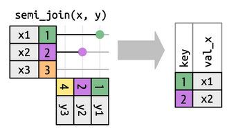

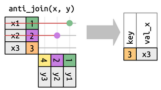

## filtering joins

Remember how we wanted to only analyze the predictions that were made by real groundhogs? We can use a filtering join! Specifically a semi join.

```r
# keep all rows in predictions that were made by a real groundhog and save the result as real_groundhog_predictions
real_groundhog_predictions <- semi_join(predictions, groundhogs |> filter(is_groundhog == TRUE), join_by(id == id))
```

## more complex join conditions

- Within `join_by()`, we can use more complex conditions than whether `key == key`
- You can use other numeric operations like `>`, `<`, etc.
- The `closest()` function matches the closest key to another key based on some criteria (closest value at all, closest value that is larger, etc.)
- `between()` and `within()` can test whether a value falls between two other values. This is useful if you want to join events that happened within a given time span.

## other table verbs

- `bind_rows()` pastes rows onto the bottom of a dataframe
  - the dataframes must have the same columns
- `bind_cols()` pastes columns onto the right of a dataframe.
- There are no conditions in these functions, you can think of them as copy-and-paste.

## 🏁 finish line

Let’s put everything we’ve learned together!

Let’s re-create our summary table with the percent of shadows seen each year, this time only including real groundhogs in our calculation, and save the result as groundhog_predictions_summary

## 🏁 finish line

```r
groundhog_predictions_summary <- real_groundhog_predictions |>
  group_by(year) |>
  summarize(n_predictions = n(),
            n_shadows = sum(shadow == TRUE)) |>
  mutate(percent_shadow = n_shadows/n_predictions) |>
  arrange(desc(year))
```

## 💾 saving our dataset

We’ve created a dataset that is ready to be compared with yearly weather trends! Let’s save it to a csv so we can use it into the future.

```r
write.csv(groundhog_predictions_summary, "groundhog_predictions_summary.csv")
```

## 🏆 bonus exercises

- Write code to calculate the column `predictions_count` in `groundhogs`
- Write code to calculate the column `is_groundhog` in `groundhogs`
- Calculate the proportion of groundhogs from each country that make predictions each year
- Add a column to groundhogs indicating the first year each groundhog saw its shadow
- Create a summary table showing the first year each type of groundhog made a prediction

## summary: verbs & helper functions

**Verbs:**

- `filter()` , `arrange()` , `distinct()`
- `group_by()` , `summarize()`
- `mutate()` , `select()`, `rename()`
- `left_`, `right_`, `inner_`, `full_`, `semi_`, `anti_` joins
- `bind` `_rows` and `_cols`

**Helper functions:**

- `desc()`
- `n()`, `n_distinct()`, `min()`, `max()` , `sum()`
- `if_else()` and `case_when()`
- `between()` and `within()`

## thank you! 🙏

Please take the post-workshop survey:

[figure not shown]

**Future trainings:**

- [Interactive Data Visualization in R with Shiny](https://jhu.libcal.com/calendar/workshops/data-vis-shiny): 10/5, 10/7, & 10/9 10am - 12pm
- [Creating Automated Reports in R: An Introduction to Quarto](https://jhu.libcal.com/calendar/workshops/quarto): 10/28 12pm - 1pm